# Plotting in RMODFLOW

Cas Neyens

2021-08-19

# Plotting basic RMODFLOW objects

RMODFLOW provides S3 plotting methods through the `rmf_plot()` functions. These return a `ggplot2` layer and are therefore subjected to the full capabilities of the `ggplot2` package.

For almost all `rmf_plot` functions, you’ll need a RMODFLOW `dis` object. There are `rmf_plot` functions for a bunch of RMODFLOW classes but at their core they most of the time wrangle the object into a `rmf_2d_array` or `rmf_3d_array` and call the respective `rmf_plot` function on those objects.

We’ll start by explaining plotting the basic RMODFLOW classes, i.e. the `rmf_arrays` and `rmf_list`. You can read more about these types of objects in the vignette on the structure of input data.

### `rmf_2d_array`

The `rmf_plot.rmf_2d_array()` plotting function plots a `rmf_2d_array`:

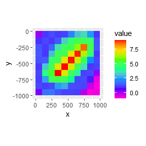

```r
dis <- rmf_example_model("example-model.dis") %>%
  rmf_read_dis()

rmf_plot(dis$top, dis = dis)
```

The `type` argument controls the plot type. Possible values are `fill` (default), `factor`, `grid`, `contour` and `vector`. At this point, it is good to note that `fill` and `factor` use the fill aesthetic from `ggplot2` whereas `grid`, `contour` and `vector` use the colour aesthetic.

#### Factor

The `factor` type is useful for discrete data. It coerces the values in the `rmf_2d_array` into factors. Plotting can therefore be slow if the array holds many distinct values. In that case however, you should consider using the `fill` type. You can supply a `levels` argument to label the legend wich is a character vector with the labels. If not named, the values in this vector are assigned to the sorted array factor levels.

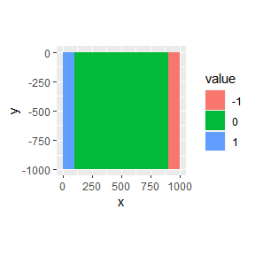

```r
ds <- rmf_create_array(0, dim = c(dis$nrow, dis$ncol))
ds[, 1] <- 1
ds[, dis$ncol] <- -1

rmf_plot(ds, dis = dis, type = "factor")
```

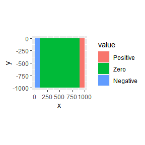

```r
# not named; labels are assigned to sorted factor levels
lv <- c("Positive", "Zero", "Negative")
rmf_plot(ds, dis = dis, type = "factor", levels = lv)
```

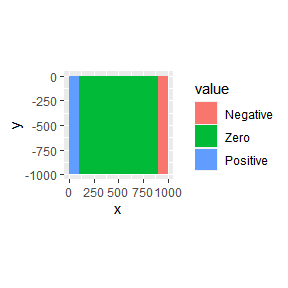

```r
# named
lv <- c("1" = "Positive", "0" = "Zero", "-1" = "Negative")
rmf_plot(ds, dis = dis, type = "factor", levels = lv)
```

#### Grid

The `grid` type will only plot the gridlines.

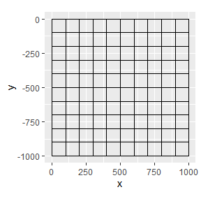

```r
rmf_plot(dis$top, dis = dis, type = "grid")
```

To plot gridlines on top of an existing plot, the quickest way is to set the `gridlines` argument to `TRUE`. Alternatively, you can supply a character argument to plot coloured gridlines

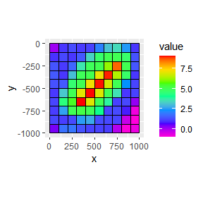

```r
rmf_plot(dis$top, dis = dis, gridlines = TRUE)
```

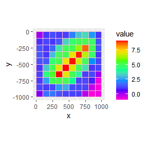

```r
rmf_plot(dis$top, dis = dis, gridlines = "pink")
```

#### Contour

The `contour` type will plot contour lines. You can tweak the `binwidth` argument to your liking (the defaults might not always work). Additionally, the labels can be removed by setting `label = FALSE`

[figure not shown]

```r
rmf_plot(dis$top, dis = dis, type = "contour")

```

[figure not shown]

```r
rmf_plot(dis$top, dis = dis, type = "contour", binwidth = 2, label = FALSE)
```

#### Vector

The `vector` type will calculate a gradient using `rmf_gradient()` and will plot the vector arrows using `ggquiver`. Note that RMODFLOW assumes the array contains scalars to calculate the gradient. To supply your own vector values, you can set the `uvw` argument which is a named list with u and v components (and w for 3d) which are 2d (3d) arrays with the gradient values in the x and y (& z) directions.

```r
rmf_plot(dis$top, dis = dis, type = "vector")
```

[output not shown]

```r
rmf_plot(dis$top, dis = dis, type = "vector", vecint = 3)
```

[output not shown]

```r
u <- rmf_create_array(0.5, dim = c(dis$nrow, dis$ncol))
v <- rmf_create_array(-1, dim = c(dis$nrow, dis$ncol))
uvw <- list(u = u, v = v)

rmf_plot(dis$top, dis = dis, type = "vector", uvw = uvw)
```

[output not shown]

#### Colour palette

You can specify your own colour palette and the number of colours with `colour_palette` and `nlevels` (7 by default). For type `grid`, no colour scale can be supplied. For type `contour` and type `vector`, the default colour scale is `'black'` which is not a scale at all.

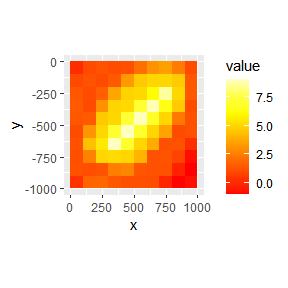

```r
rmf_plot(dis$top, dis = dis, colour_palette = heat.colors, nlevels = 8)
```

```r
rmf_plot(dis$top, dis = dis, colour_palette = heat.colors, nlevels = 8, type = 'vector')
```

[output not shown]

#### Mask & bas

You can supply a logical array as the `mask` argument to only include certain parts of the grid. If not supplied, the entire grid is plotted. If a `bas` object is supplied, the ibound array is used as a `mask` object.

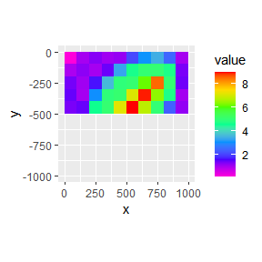

```r
mask <- rmf_create_array(0, dim = c(dis$nrow, dis$ncol))
mask[1:dis$nrow/2, ] <- 1

rmf_plot(dis$top, dis = dis, mask = mask)
```

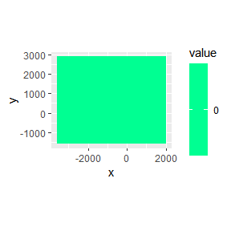

```r
# water-supply problem
dis_ws <- rmf_example_file("water-supply-problem.dis") %>%
  rmf_read_dis()
bas_ws <- rmf_example_file("water-supply-problem.bas") %>%
  rmf_read_bas(dis = dis_ws)

# without bas
rmf_plot(dis_ws$top, dis = dis_ws)
```

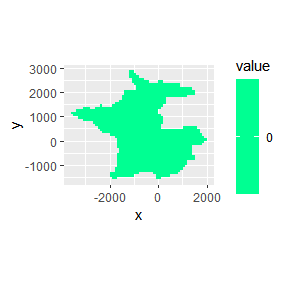

```r
# with bas
rmf_plot(dis_ws$top, dis = dis_ws, bas = bas_ws)
```

#### Adding plot layers

Since all `rmf_plot` functions return a `ggplot2` layer, you can add them on top of each other. Just remember to set `add = TRUE` in all added layers. You can of course add other `ggplot2` layers besides the `rmf_plot` results.

[figure not shown]

```r
rmf_plot(dis$top, dis = dis) +
  rmf_plot(dis$top, dis = dis, type = "vector", add = TRUE)
```

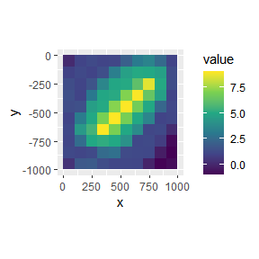

```r
rmf_plot(dis$top, dis = dis) +
  ggplot2::scale_fill_viridis_c()
```

#### Legend

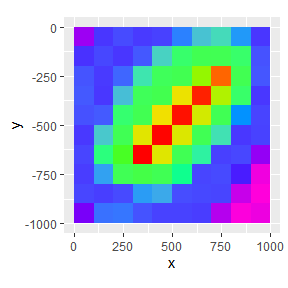

```r
rmf_plot(dis$top, dis = dis, legend = FALSE)
```

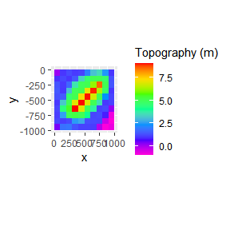

```r
rmf_plot(dis$top, dis = dis, legend = "Topography (m)")
```

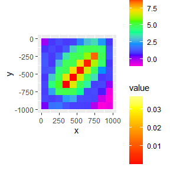

```r
# This also works for added layers:
rmf_plot(dis$top, dis = dis) +
  rmf_plot(dis$top, dis = dis, type = "vector", add = TRUE, colour_palette = heat.colors, legend = TRUE)
```

#### Projection

Waiting for update on spatial code

#### 3D plotting

3D plotting: currently being moved around in the code, possibly with different function `rmf_render`.

### `rmf_3d_array`

Plotting a `rmf_3d_array` with `rmf_plot.rmf_3d_array()` uses mostly the same functionality as plotting a `rmf_2d_array`. The big difference being that now you **must** supply either a `i`, `j` or `k` integer argument which subsets the `rmf_3d_array`. If `k` is supplied, the subsetted array is passed to `rmf_2d_array`. If `i` or `j` are supplied, a cross-section is plotted:

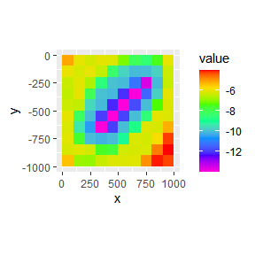

```r
rmf_plot(dis$botm, dis = dis, k = 1)
```

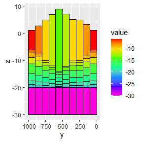

```r
rmf_plot(dis$botm, dis = dis, j = 5, gridlines = TRUE)
```

All other arguments discussed with plotting `rmf_2d_arrays` can still be used. Note however, that when adding plot layers, they must have the same subset otherwise the plots make no sense or might error out. RMODFLOW does not have a check for this.

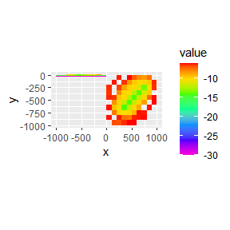

```r
# layer 1 + column 5
rmf_plot(dis$botm, dis = dis, k = 1) +
  rmf_plot(dis$botm, dis = dis, j = 5, add = TRUE)
```

### `rmf_4d_array`

Plotting a `rmf_4d_array` with `rmf_plot.rmf_4d_array()` works much like plotting a `rmf_3d_array`: the user must supply a `i`, `j` or `k` integer. Additionally, a `l` integer must be supplied to subset the 4th dimension. If not present, the last time step will be plotted.

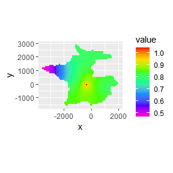

```r
hed <- rmf_example_file("water-supply-problem.fhd") %>%
  rmf_read_hed(dis = dis_ws, binary = FALSE)

rmf_plot(hed, dis = dis_ws, bas = bas_ws, k = 1)
```

[figure not shown]

```r
rmf_plot(hed, dis = dis_ws, bas = bas_ws, j = 5, l = 10)
```

If `i`, `j` and `k` are supplied and no `l` is supplied, a time-series is plotted of cell ijk:

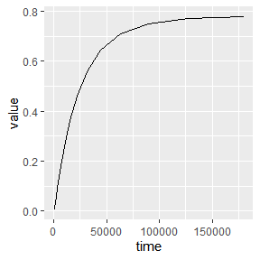

```r
rmf_plot(hed, dis = dis_ws, i = 20, j = 25, k = 1)
```

## `rmf_list`

When a `rmf_list` is plotted, it is converted to a `rmf_3d_array` using `rmf_as_array()` with `sparse = FALSE`. There are three arguments in `rmf_plot.rmf_list()` that you need to know about.

First, the `variable` argument, which is either an integer or a character name, specifies which column of the `rmf_list` to plot. The default, `'id'`, does not plot a variable but the locations of the cells in the `rmf_list`.

Secondly, `active_only` is a logical dictating how to handle the cells not present in the `rmf_list`. The default (`FALSE`) sets all non-active cells to 0. If `TRUE`, these cells are set to `NA`.

Lastly, the `fun` argument indicates how to handle duplicate cells. In a `rmf_list`, multiple instances of the same cell may appear. For instance, there can be multiple wells in a single MODFLOW cell. When plotting a variable, the `fun` argument specifies how to aggregate these values. The default is `sum`, but you can specify any function that returns a single numeric from one or more values (e.g. `mean`).

Since `rmf_plot.rmf_list` eventually calls `rmf_plot.rmf_3d_array` you can pass arguments for the latter as well.

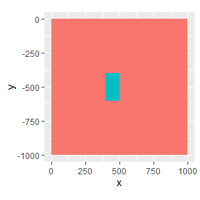

```r
ls <- data.frame(i = c(5, 5, 6),
                 j = 5,
                 k = 1,
                 q = c(-500, -500, -1500)) %>%
  rmf_create_list()

rmf_plot(ls, dis = dis, k = 1)
```

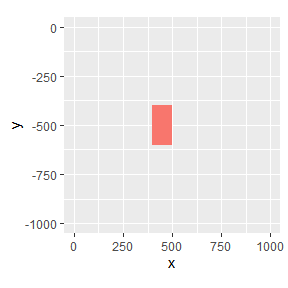

```r
rmf_plot(ls, dis = dis, k = 1, active_only = TRUE)
```

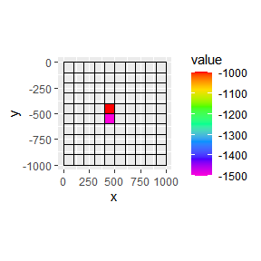

```r
rmf_plot(ls, dis = dis, k = 1, variable = 'q', active_only = TRUE, gridlines = TRUE)
```

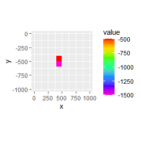

```r
# fun = mean, notice change in scale
rmf_plot(ls, dis = dis, k = 1, variable = 'q', active_only = TRUE, fun = mean)
```

# Plotting boundary condition packages

As discussed in the vignette on boundary conditions, MODFLOW boundary conditions can be grouped into those representing continuous spatial features and those representing discrete spatial features. The former will be plotted by `rmf_plot.rmf_2d_array`; the latter by `rmf_plot.rmf_list`. By default, the last stress-period is plotted; this can be overwritten by setting the `kper` argument. The variables which can be plotted depend on the package.

## Continuous boundary conditions

For continuous boundary conditions, the S3 plotting methods are simple wrappers for `rmf_plot.rmf_2d_array` with an additional `kper` and `variable` argument. The `variable` is set to sensible defaults for every package, e.g. `'recharge'` for the RCH package.

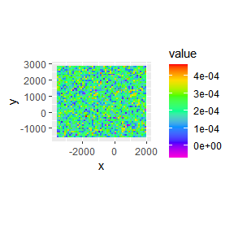

```r
rch <- rnorm(dis_ws$nrow*dis_ws$ncol, mean = 0.0002, sd = 0.00008) %>%
  rmf_create_array(dim = c(dis_ws$nrow, dis_ws$ncol), kper = 1) %>%
  rmf_create_rch(dis = dis_ws)

rmf_plot(rch, dis = dis_ws)
```

## Discrete boundary conditions

Concerning the discrete boundary conditions, the respective S3 plotting methods will set sensible defaults for the `rmf_plot.rmf_list` arguments. By default, `variable = 'id'` which plots the locations of the boundary condition cells; `active_only = TRUE` and the `fun` argument is set based on the variable that’s plotted which can differ between boundary conditions. In general, if the variable is conductance, `fun = sum`, otherwise `fun = mean`.

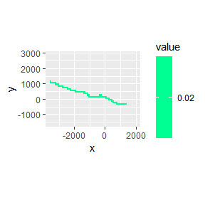

```r
riv_ws <- rmf_example_file("water-supply-problem.riv") %>%
   rmf_read_riv(dis = dis_ws)

rmf_plot(riv_ws, dis = dis_ws, k = 1, variable = 'conductance')
```

# Plotting flow packages

There are no S3 plotting methods for the BCF, LPF and NWT packages. Simply plot the arrays you want by calling `rmf_plot` on them directly:

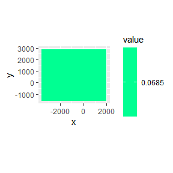

```r
lpf_ws <- rmf_example_file("water-supply-problem.lpf") %>%
  rmf_read_lpf(dis = dis_ws)

rmf_plot(lpf_ws$hk, dis = dis_ws, k = 1)
```

For the HUF package however, there is a S3 plotting method: `rmf_plot.huf()`. By default, it plots the hydrogeological units (hgu’s) using `type = 'factor'`. The `levels` argument is set to the names of the hgu’s provided by `huf$hgunam`. You can select rows, columns & layer with `i`, `j` & `k` as with normal `rmf_plot` functions. You can subset prefered hgu’s with the `hgu` argument which accepts either integers or character names of the hgu to plot. By default, the mask object is provided by `rmf_convert_huf_to_mask()`.

```r
# No example problem with HUF package atm
```

# Plotting output

Plotting output is shown in the vignette on output handling.

# Plotting MODFLOW models

To quickly have a glance at an entire MODFLOW model that’s been read in, `rmf_plot` also has a S3 method for the `modflow` class. This plots the IBOUND array and the discrete boundary condition packages that are active. Continuous boundary conditions like RCH and EVT are not plotted since that would overwhelm to plot. You have to select a i, j or k section to plot:

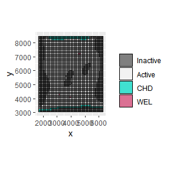

```r
m <- rmf_example_file("rocky-mountain-arsenal.nam") %>%
  rmf_read(verbose = FALSE)

rmf_plot(m, k = 1)
```

If you wish to omit a certain package, specify the `omit` argument which takes a character vector as input. Note that it requires MODFLOW abbreviations for the packages, like the `ftype` in the NAME file:

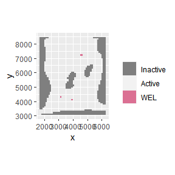

```r
rmf_plot(m, k = 1, omit = 'CHD', gridlines = FALSE)
```

Lastly, in some models, not all boundary conditions are present in all layers. For example, wells are often present in deeper layers. Instead of plotting all layers separately to view them, we can reproject all boundary condition cells to the current layer when the `k` index is given by setting `to_k = TRUE`. Note that the IBOUND is not reprojected.

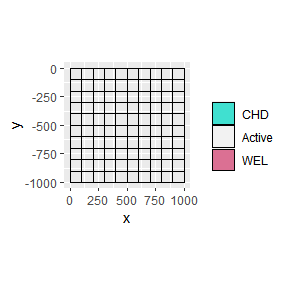

```r
m <- rmf_example_file("example-model.nam") %>%
  rmf_read(verbose = FALSE)

# nothing in layer 2
rmf_plot(m, k = 2)
```

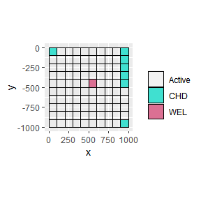

```r
# force showing all
rmf_plot(m, k = 2, to_k = TRUE)
```